# A7_Tadepalli_Sai_Eshwar

Sai Eshwar Tadepalli

2023-07-23

## Task I - EDA

Perform exploratory data analysis on the dataset. Add text to note items from code blocks you have observed.

```r
library(rmarkdown)
library(psych)
library(scatterplot3d)
library(caret)
library(C50)
library(rminer)
library(e1071)
library(matrixStats)
library(knitr)
library(rpart)
library(kernlab)
library(arules)
library(tictoc)
tic()

# Setting up working directory
cloud_wd <- getwd()
setwd(cloud_wd)

# Importing Data
census_data <- read.csv(file = "census.csv", stringsAsFactors = FALSE)
str(census_data)
```

```
## 'data.frame':    32561 obs. of  15 variables:
##  $ age           : int  39 50 38 53 28 37 49 52 31 42 ...
##  $ workclass     : chr  " State-gov" " Self-emp-not-inc" " Private" " Private" ...
##  $ fnlwgt        : int  77516 83311 215646 234721 338409 284582 160187 209642 45781 159449 ...
##  $ education     : chr  " Bachelors" " Bachelors" " HS-grad" " 11th" ...
##  $ education.num : int  13 13 9 7 13 14 5 9 14 13 ...
##  $ marital.status: chr  " Never-married" " Married-civ-spouse" " Divorced" " Married-civ-spouse" ...
##  $ occupation    : chr  " Adm-clerical" " Exec-managerial" " Handlers-cleaners" " Handlers-cleaners" ...
##  $ relationship  : chr  " Not-in-family" " Husband" " Not-in-family" " Husband" ...
##  $ race          : chr  " White" " White" " White" " Black" ...
##  $ sex           : chr  " Male" " Male" " Male" " Male" ...
##  $ capital.gain  : int  2174 0 0 0 0 0 0 0 14084 5178 ...
##  $ capital.loss  : int  0 0 0 0 0 0 0 0 0 0 ...
##  $ hours.per.week: int  40 13 40 40 40 40 16 45 50 40 ...
##  $ native.country: chr  " United-States" " United-States" " United-States" " United-States" ...
##  $ y             : chr  " <=50K" " <=50K" " <=50K" " <=50K" ...
```

```r
# Converting character into factors
census_data$workclass = factor(census_data$workclass)
census_data$education = factor(census_data$education)
census_data$marital.status = factor(census_data$marital.status)
census_data$occupation = factor(census_data$occupation)
census_data$relationship = factor(census_data$relationship)
census_data$race = factor(census_data$race)
census_data$sex = factor(census_data$sex)
census_data$native.country = factor(census_data$native.country)
census_data$y = factor(census_data$y)

#View(census_data)

# There are ? in the dataframe so it can be done in two ways, one keeping ? as it is and other one is changing ? to some variable

census_data_cleaned <- census_data

summary(census_data_cleaned)
```

```
##       age                    workclass         fnlwgt
##  Min.   :17.00    Private         :22696   Min.   :  12285
##  1st Qu.:28.00    Self-emp-not-inc: 2541   1st Qu.: 117827
##  Median :37.00    Local-gov       : 2093   Median : 178356
##  Mean   :38.58    ?               : 1836   Mean   : 189778
##  3rd Qu.:48.00    State-gov       : 1298   3rd Qu.: 237051
##  Max.   :90.00    Self-emp-inc    : 1116   Max.   :1484705
##                  (Other)          :  981
##          education     education.num                  marital.status
##   HS-grad     :10501   Min.   : 1.00    Divorced             : 4443
##   Some-college: 7291   1st Qu.: 9.00    Married-AF-spouse    :   23
##   Bachelors   : 5355   Median :10.00    Married-civ-spouse   :14976
##   Masters     : 1723   Mean   :10.08    Married-spouse-absent:  418
##   Assoc-voc   : 1382   3rd Qu.:12.00    Never-married        :10683
##   11th        : 1175   Max.   :16.00    Separated            : 1025
##  (Other)      : 5134                    Widowed              :  993
##             occupation            relationship                    race
##   Prof-specialty :4140    Husband       :13193    Amer-Indian-Eskimo:  311
##   Craft-repair   :4099    Not-in-family : 8305    Asian-Pac-Islander: 1039
##   Exec-managerial:4066    Other-relative:  981    Black             : 3124
##   Adm-clerical   :3770    Own-child     : 5068    Other             :  271
##   Sales          :3650    Unmarried     : 3446    White             :27816
##   Other-service  :3295    Wife          : 1568
##  (Other)         :9541
##       sex         capital.gain    capital.loss    hours.per.week
##   Female:10771   Min.   :    0   Min.   :   0.0   Min.   : 1.00
##   Male  :21790   1st Qu.:    0   1st Qu.:   0.0   1st Qu.:40.00
##                  Median :    0   Median :   0.0   Median :40.00
##                  Mean   : 1078   Mean   :  87.3   Mean   :40.44
##                  3rd Qu.:    0   3rd Qu.:   0.0   3rd Qu.:45.00
##                  Max.   :99999   Max.   :4356.0   Max.   :99.00
##
##         native.country       y
##   United-States:29170    <=50K:24720
##   Mexico       :  643    >50K : 7841
##   ?            :  583
##   Philippines  :  198
##   Germany      :  137
##   Canada       :  121
##  (Other)       : 1709
```

```r
census_data_cleaned[sapply(census_data_cleaned,is.factor)] <- data.frame(lapply(census_data_cleaned[sapply(census_data_cleaned,is.factor)], function(x) {gsub("\\?","Other",x) }),stringsAsFactors = TRUE)

#View(census_data_cleaned)

str(census_data_cleaned)
```

```
## 'data.frame':    32561 obs. of  15 variables:
##  $ age           : int  39 50 38 53 28 37 49 52 31 42 ...
##  $ workclass     : Factor w/ 9 levels " Federal-gov",..: 8 7 5 5 5 5 5 7 5 5 ...
##  $ fnlwgt        : int  77516 83311 215646 234721 338409 284582 160187 209642 45781 159449 ...
##  $ education     : Factor w/ 16 levels " 10th"," 11th",..: 10 10 12 2 10 13 7 12 13 10 ...
##  $ education.num : int  13 13 9 7 13 14 5 9 14 13 ...
##  $ marital.status: Factor w/ 7 levels " Divorced"," Married-AF-spouse",..: 5 3 1 3 3 3 4 3 5 3 ...
##  $ occupation    : Factor w/ 15 levels " Adm-clerical",..: 1 4 6 6 11 4 9 4 11 4 ...
##  $ relationship  : Factor w/ 6 levels " Husband"," Not-in-family",..: 2 1 2 1 6 6 2 1 2 1 ...
##  $ race          : Factor w/ 5 levels " Amer-Indian-Eskimo",..: 5 5 5 3 3 5 3 5 5 5 ...
##  $ sex           : Factor w/ 2 levels " Female"," Male": 2 2 2 2 1 1 1 2 1 2 ...
##  $ capital.gain  : int  2174 0 0 0 0 0 0 0 14084 5178 ...
##  $ capital.loss  : int  0 0 0 0 0 0 0 0 0 0 ...
##  $ hours.per.week: int  40 13 40 40 40 40 16 45 50 40 ...
##  $ native.country: Factor w/ 42 levels " Cambodia"," Canada",..: 40 40 40 40 5 40 23 40 40 40 ...
##  $ y             : Factor w/ 2 levels " <=50K"," >50K": 1 1 1 1 1 1 1 2 2 2 ...
```

```r
summary(census_data_cleaned)
```

```
##       age                    workclass         fnlwgt
##  Min.   :17.00    Private         :22696   Min.   :  12285
##  1st Qu.:28.00    Self-emp-not-inc: 2541   1st Qu.: 117827
##  Median :37.00    Local-gov       : 2093   Median : 178356
##  Mean   :38.58    Other           : 1836   Mean   : 189778
##  3rd Qu.:48.00    State-gov       : 1298   3rd Qu.: 237051
##  Max.   :90.00    Self-emp-inc    : 1116   Max.   :1484705
##                  (Other)          :  981
##          education     education.num                  marital.status
##   HS-grad     :10501   Min.   : 1.00    Divorced             : 4443
##   Some-college: 7291   1st Qu.: 9.00    Married-AF-spouse    :   23
##   Bachelors   : 5355   Median :10.00    Married-civ-spouse   :14976
##   Masters     : 1723   Mean   :10.08    Married-spouse-absent:  418
##   Assoc-voc   : 1382   3rd Qu.:12.00    Never-married        :10683
##   11th        : 1175   Max.   :16.00    Separated            : 1025
##  (Other)      : 5134                    Widowed              :  993
##             occupation            relationship                    race
##   Prof-specialty :4140    Husband       :13193    Amer-Indian-Eskimo:  311
##   Craft-repair   :4099    Not-in-family : 8305    Asian-Pac-Islander: 1039
##   Exec-managerial:4066    Other-relative:  981    Black             : 3124
##   Adm-clerical   :3770    Own-child     : 5068    Other             :  271
##   Sales          :3650    Unmarried     : 3446    White             :27816
##   Other-service  :3295    Wife          : 1568
##  (Other)         :9541
##       sex         capital.gain    capital.loss    hours.per.week
##   Female:10771   Min.   :    0   Min.   :   0.0   Min.   : 1.00
##   Male  :21790   1st Qu.:    0   1st Qu.:   0.0   1st Qu.:40.00
##                  Median :    0   Median :   0.0   Median :40.00
##                  Mean   : 1078   Mean   :  87.3   Mean   :40.44
##                  3rd Qu.:    0   3rd Qu.:   0.0   3rd Qu.:45.00
##                  Max.   :99999   Max.   :4356.0   Max.   :99.00
##
##         native.country       y
##   United-States:29170    <=50K:24720
##   Mexico       :  643    >50K : 7841
##   Other        :  583
##   Philippines  :  198
##   Germany      :  137
##   Canada       :  121
##  (Other)       : 1709
```

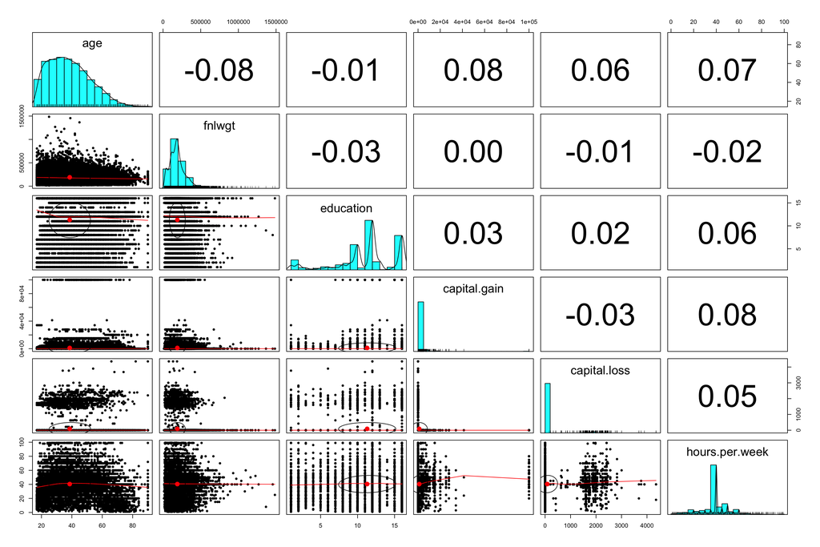

```r
# Correlation Analysis
pairs.panels(census_data[c(1,3,4,11:13)])
```

```r
# Check for any NA's
na_counts <- colSums(is.na(census_data_cleaned))
na_counts
```

```
##            age      workclass         fnlwgt      education  education.num
##              0              0              0              0              0
## marital.status     occupation   relationship           race            sex
##              0              0              0              0              0
##   capital.gain   capital.loss hours.per.week native.country              y
##              0              0              0              0              0
```

## Task II Data Preparation:

Prepare your data for modeling.

```r
set.seed(500)
inTrain <- createDataPartition(census_data$y, p=0.7, list=FALSE)
inTrain_cleaned <- createDataPartition(census_data_cleaned$y, p=0.7, list=FALSE)

censusTrain <- census_data[inTrain,]
censusTest <- census_data[-inTrain,]
censusTrain_cleaned <- census_data_cleaned[inTrain_cleaned,]
censusTest_cleaned <- census_data_cleaned[-inTrain_cleaned,]
```

## Task III - Model Building

Build a variety of models and keep them to show your efforts to achieve good performance. Your stakeholders prefer interpretability over performance. Consider this as you choose your models. How many models are sufficient? Enough to show that you found underfitting, overfitting and a good balance between the two. Your stakeholders still want a good model however.

Using Navie Bayes as first model for uncleaned data

```r
# Using the train set to build a model
census_nb <- naiveBayes(y~., censusTrain)
census_nb
```

```
##
## Naive Bayes Classifier for Discrete Predictors
##
## Call:
## naiveBayes.default(x = X, y = Y, laplace = laplace)
##
## A-priori probabilities:
## Y
##     <=50K      >50K
## 0.7591805 0.2408195
##
## Conditional probabilities:
##         age
## Y            [,1]     [,2]
##    <=50K 36.71648 14.01395
##    >50K  44.28694 10.56866
##
##         workclass
## Y                   ?  Federal-gov    Local-gov  Never-worked      Private
##    <=50K 0.0663430421 0.0239251040 0.0578478964  0.0003467406 0.7186777624
##    >50K  0.0240480962 0.0473674622 0.0770632173  0.0000000000 0.6338130807
##         workclass
## Y         Self-emp-inc  Self-emp-not-inc    State-gov  Without-pay
##    <=50K  0.0190129450      0.0747803976 0.0384304207 0.0006356912
##    >50K   0.0788850428      0.0921843687 0.0466387320 0.0000000000
##
##         fnlwgt
## Y            [,1]     [,2]
##    <=50K 190866.5 106570.1
##    >50K  188391.3 102191.7
##
##         education
## Y                10th         11th         12th      1st-4th      5th-6th
##    <=50K 0.0373324087 0.0455963939 0.0158922792 0.0067036523 0.0136384651
##    >50K  0.0083803972 0.0076516670 0.0043723811 0.0005465476 0.0021861906
##         education
## Y             7th-8th          9th   Assoc-acdm    Assoc-voc    Bachelors
##    <=50K 0.0238095238 0.0198797966 0.0331137309 0.0417244568 0.1246532594
##    >50K  0.0052832939 0.0029149208 0.0344325014 0.0464565495 0.2820185826
##         education
```

[output cut: 98 more lines]

```
## Y             Jamaica        Japan         Laos       Mexico    Nicaragua
##    <=50K 0.0026005548 0.0016181230 0.0006356912 0.0252542765 0.0012135922
##    >50K  0.0012752778 0.0038258335 0.0003643651 0.0043723811 0.0001821825
##         native.country
## Y         Outlying-US(Guam-USVI-etc)         Peru  Philippines       Poland
##    <=50K                0.0005779011 0.0013291724 0.0053744799 0.0019648636
##    >50K                 0.0000000000 0.0001821825 0.0085625797 0.0014574604
##         native.country
## Y            Portugal  Puerto-Rico     Scotland        South       Taiwan
##    <=50K 0.0011558021 0.0039875173 0.0003467406 0.0026005548 0.0009824318
##    >50K  0.0007287302 0.0010930953 0.0003643651 0.0021861906 0.0025505557
##         native.country
## Y            Thailand  Trinadad&Tobago  United-States      Vietnam   Yugoslavia
##    <=50K 0.0004623209     0.0007512714   0.8907189089 0.0023693944 0.0002889505
##    >50K  0.0003643651     0.0001821825   0.9174713062 0.0007287302 0.0007287302
```

```r
# Applying the model to the hold-out test set and generate holdout evaluation metrics
predicted_test1 <- predict(census_nb, censusTest)
mmetric(censusTest$y, predicted_test1, metric=c("ACC","TPR","PRECISION","F1"))
```

```
##        ACC       TPR1       TPR2 PRECISION1 PRECISION2        F11        F12
##   83.21048   93.25782   51.53061   85.84906   70.79439   89.40021   59.64567
```

```r
# For comparison, applying the model to the train set and generate evaluation metrics.
predicted_y_train1 <- predict(census_nb, censusTrain)
mmetric(censusTrain$y, predicted_y_train1, metric=c("ACC","TPR","PRECISION","F1"))
```

```
##        ACC       TPR1       TPR2 PRECISION1 PRECISION2        F11        F12
##   82.79296   93.31368   49.62653   85.37965   70.18810   89.17053   58.14301
```

> The test accuracy of 83.21% was greater than the train accuracy of 82.79%, indicating that the Naive Bayes model performed poorly on the uncleaned data. This difference implies that the model has difficulty extracting useful information from the uncleaned dataset, possibly as a result of the presence of missing values (“?”). These missing data might have impacted the model’s training process and reduced train accuracy.

Using C5.0 as second model for uncleaned data

```r
# Using the train set to build a model
census_c50 <- C5.0(y~., censusTrain)
census_c50
```

```
##
## Call:
## C5.0.formula(formula = y ~ ., data = censusTrain)
##
## Classification Tree
## Number of samples: 22793
## Number of predictors: 14
##
## Tree size: 126
##
## Non-standard options: attempt to group attributes
```

```r
# Applying the model to the hold-out test set and generate holdout evaluation metrics

predicted_y_test2 <- predict(census_c50, censusTest)
mmetric(censusTest$y, predicted_y_test2, metric=c("ACC","TPR","PRECISION","F1"))
```

```
##        ACC       TPR1       TPR2 PRECISION1 PRECISION2        F11        F12
##   87.03931   93.62190   66.28401   89.74922   76.72244   91.64467   71.12226
```

```r
# For comparison, applying the model to the train set and generate evaluation metrics.
# Check out the performance drop in the holdout set.
predicted_y_train2 <- predict(census_c50, censusTrain)
mmetric(censusTrain$y, predicted_y_train2, metric=c("ACC","TPR","PRECISION","F1"))
```

```
##        ACC       TPR1       TPR2 PRECISION1 PRECISION2        F11        F12
##   88.07529   94.55617   67.64438   90.20840   79.76369   92.33113   73.20584
```

> With a test accuracy of 87.03% being slightly lower than the train accuracy of 88.07% for the C5.0 model on the uncleaned data, the model still showcases good performance. The difference between test and train accuracy is minimal, indicating that the model generalizes well to unseen data.

Using KSVM as third model for uncleaned data

```r
# Using the train set to build a model
census_ksvm <- ksvm(y~., censusTrain)
census_ksvm
```

```
## Support Vector Machine object of class "ksvm"
##
## SV type: C-svc  (classification)
##  parameter : cost C = 1
##
## Gaussian Radial Basis kernel function.
##  Hyperparameter : sigma =  0.0766730315151983
##
## Number of Support Vectors : 7882
##
## Objective Function Value : -7028.284
## Training error : 0.134822
```

```r
# Applying the model to the hold-out test set and generate holdout evaluation metrics

predicted_y_test3 <- predict(census_ksvm, censusTest)
mmetric(censusTest$y, predicted_y_test3, metric=c("ACC","TPR","PRECISION","F1"))
```

```
##        ACC       TPR1       TPR2 PRECISION1 PRECISION2        F11        F12
##   86.30221   94.17476   61.47959   88.51711   76.99681   91.25833   68.36879
```

```r
# For comparison, applying the model to the train set and generate evaluation metrics.
# Check out the performance drop in the holdout set.
predicted_y_train3 <- predict(census_ksvm, censusTrain)
mmetric(censusTrain$y, predicted_y_train3, metric=c("ACC","TPR","PRECISION","F1"))
```

```
##        ACC       TPR1       TPR2 PRECISION1 PRECISION2        F11        F12
##   86.51779   94.70643   60.70322   88.36883   78.43691   91.42793   68.43997
```

> With a test accuracy of 86.30% being slightly lower than the train accuracy of 86.51% for the KSVM model on the uncleaned data, the model still showcases good performance. The difference between test and train accuracy is minimal, indicating that the model generalizes well to unseen data.